# RMarkdown: Write for Science!

Michael A Barrowman

28/04/2020

# 1 Introduction

Have you ever tried moving a table in Word? How about inserting an image into Google Docs? Switching between your stats program and report becoming a nightmare? Do you hate citations (Student 2020)?

# 2 What can we do?

This course will help you to transition smoothly into the world of RMarkdown, where you can do your statistical analysis and write your entire report/essay in a single document! RMarkdown takes care of things like formatting and figure/table placement for you without worrying about the nitty gritty, see Table 2.1 for details

Table 2.1: Here’s some data!

| x | y |
| --- | --- |
| 0.060 | 0.029 |
| 0.622 | 0.882 |
| 0.230 | 0.016 |
| 0.929 | 0.965 |
| 0.817 | 0.283 |
| 0.034 | 0.610 |

# 3 What can we make?

RMarkdown also unifies your output: Word, PDF, Webpage, Presentations and Posters can all come out of a singe document with the touch of a button.

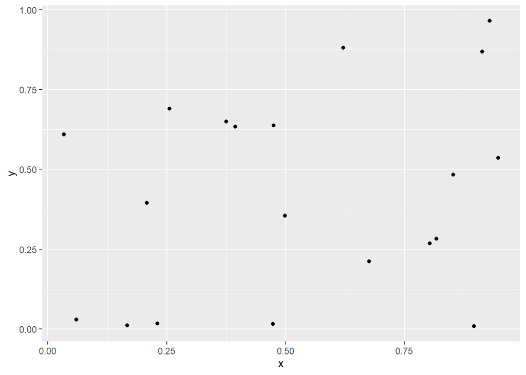

Figure 3.1: Plots are easy!

# 4 How?

# References

Student, Mr A. 2020. “How to Cite in Rmarkdown.”